# Introduction to Digital Humanities

19/05/2021

## Workshop plan:

- Start by trying to define Digital Humanities (DH)
- We’ll look at DH from the perspectives of data, analysis, and engagement
- We’ll take a look at three of the most common tools used for digital humanities:
  - Text mining
  - Network analysis
  - Mapping
- I’ll run through the key principles behind each one and give advice on tools and methods
- We’ll spend some time demo-ing easy-to-use tools designed to get you started with no prior knowledge
- Slides are available on yann-ryan.github.io/dh_intro_slides

## What is Digital Humanities?

## What is Digital Humanities?

- A discipline which emerged from ‘humanities computing’, applying computing techniques to humanities subjects. Digital humanities reflects a change in focus: it is about using digital methods to ask old questions in new ways, but also about applying humanities thinking and skills to digital methods.

From Wikipedia: The digital humanities, also known as humanities computing, is a field of study, research, teaching, and invention concerned with the intersection of computing and the disciplines of the humanities. It is methodological by nature and interdisciplinary in scope. It involves investigation, analysis, synthesis and presentation of information in electronic form. *It studies how these media affect the disciplines in which they are used, and what these disciplines have to contribute to our knowledge of computing.*

## What is Digital Humanities?

- As many definitions as there are DH practitioners! twitter.com/dhdefined

[figure not shown]

## What is Digital Humanities?

[figure not shown]

## What is Digital Humanities?

[figure not shown]

## What is Digital Humanities?

[figure not shown]

## What is Digital Humanities?

[figure not shown]

## Digital Humanities Disciplines

## Computational Literary Studies

- ‘Text mining’ works of literature to find patterns within individual texts or changes in genres or authors over time
- For example this paper looking at the changes in readability scores in the Harry Potter series, and what this says about the age of the implied readership

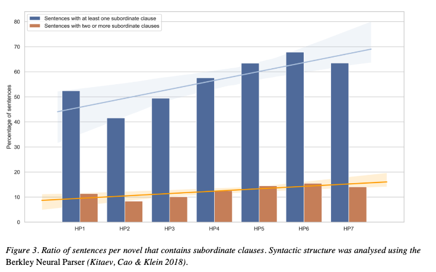

## Computational Literary Studies

## Digital History

Applying statistics or other quantitative methods to the study of the past:

- Looking at text: this paper which analysed 150 years of British newspapers looking for changing patterns

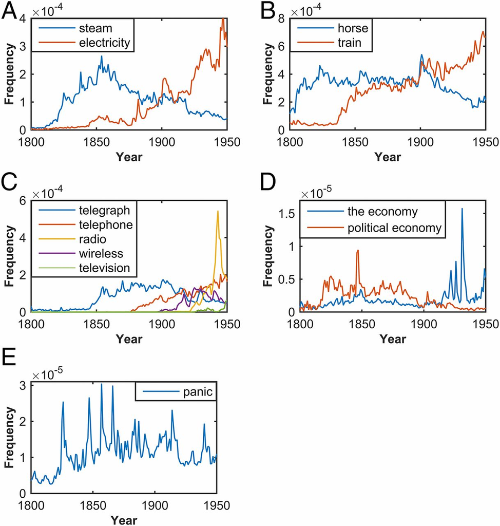

## Digital History

- Looking at other types of data, such as census records or port books:

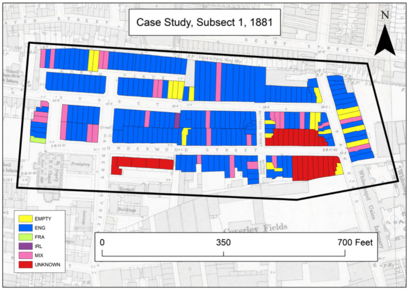

## Digital History

- Using X-Ray scanning to read unopened letters - http://letterlocking.org/

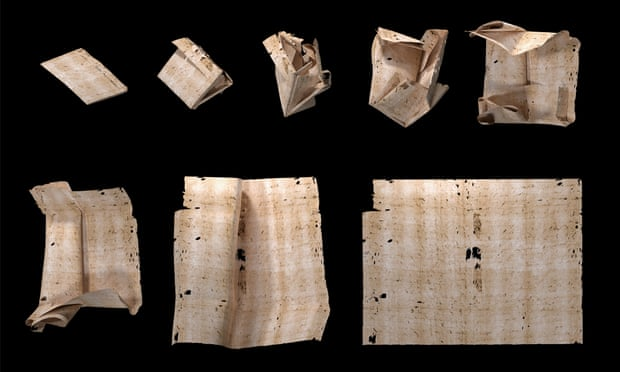

## Many other areas

- Archaeology
- Gaming
- Digital resources are also considered digital humanities:
- Creating a digital ‘edition’ or a web resource for others to use.
- Digital exhibitions and virtual worlds

## To do DH you need data…

## Types of datasets

- Full-text datasets
- Metadata datasets (collections as data
- Image datasets

## Text datasets

- A *corpus* is a collection of single *texts* or *documents.*
- Documents could be a book, a newspaper article, or a poem
- Range of *corpora* online
  - Project Gutenberg (https://www.gutenberg.org/) contains thousands of free full-text out of copyright books
  - Google N-gram datasets (https://storage.googleapis.com/books/ngrams/books/datasetsv3.html)
  - Hathi trust datasets (https://www.hathitrust.org/datasets
  - Library of Congress Newspapers - ‘Chronicling America’ (https://chroniclingamerica.loc.gov/)
  - British Library: https://data.bl.uk/bl_labs_datasets/
  - National Library of Australia’s Trove: (https://trove.nla.gov.au/)
  - KB Netherlands Labs: https://lab.kb.nl/datasets
  - Constellate

## Metadata datasets

- Cultural heritage datasets - eg newspaper title list
- Network datasets - http://emlo.bodleian.ox.ac.uk/home

## Image datasets

- KB labs (https://lab.kb.nl/datasets)
- ImageNet (https://www.image-net.org/)
- British Library Flickr: https://www.flickr.com/photos/britishlibrary

## Creating your own

- Software to collect and organise data
- Zotero
- Omeka
- Recogito

## Creating your own dataset: what to think about:

- What type of data is it? Is it structured or unstructured?
- What is the purpose?
- Who is the intended audience?
- Where is it going to live, particularly after the end of your project?
- What would other researchers need to know to use it?
- Are there copyright or ethics issues?

## Breakout Session 1:

- In small groups, discuss: do you consider your research ‘data’?
- What would you need to do to turn your data into something you could use with DH? Think about:
- Is it structured or unstructured?
- Are there ethical or copyright concerns?
- How would you use it?

## Data cleaning

- Humanities datasets are often ‘messy’: spelling variations, transcription errors, input errors can have serious effects on resulting analysis
- Because of this most datasets need data ‘cleaning’ before they can be used.
- not the best phrase because it implies something essential but boring. Data cleaning can be a key aspect of a DH project
- There are a number of tools: excel, OpenRefine, R, Python, Regular Expressions

## Data cleaning

- OpenRefine (https://openrefine.org/) is probably the best tool for dealing with ‘messy’ data
- R and Python both have advanced inbuilt tools for manipulating text
- Regular Expressions (https://www.regular-expressions.info/) are a powerful tool for finding and replacing patterns in text

[figure not shown]

## Where to get help with other datasets

- British Library datasets: https://data.bl.uk/bl_labs_datasets/
- Github e.g: https://github.com/awesomedata/awesome-public-datasets
- Journal of Open Humanities data: https://openhumanitiesdata.metajnl.com/

## Digital Humanities Tools

## Some common Digital Humanities Tools:

- Text mining
- Mapping
- Network analysis
- Data analysis & visualisation
- Machine learning
- Natural Language Processing
- Computer vision
- Virtual Reality/Augmented Reality

## Networking Archives project

- Working on a project called *Networking Archives*, which is assembling a dataset of c.450,000 letters in one place and using them to write new histories of seventeenth century ‘intelligencing’.
- We’re using the data to understand the shape of the state archives, uncover letters by spies, and map the geography of the news in 17th century Britain.

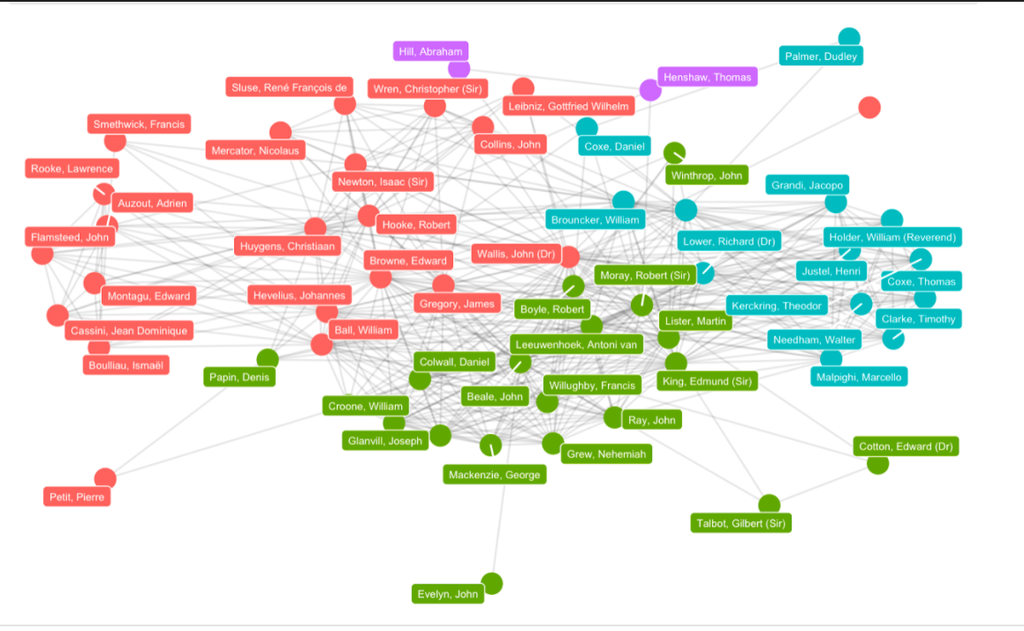

## Text mining

- Perhaps the most common digital humanities method?
- Many of the techniques taken from *information retrieval* and *Natural Language Processing*
- Used primariy in the disciplines of literature and history
- Some of the most common techniques include:
  - Lexical analysis (analysing word frequencies in texts)
  - Sentiment analysis
  - Topic modelling
  - Natural Language Processing

## Lexical analysis

- At it’s most basic, counting the frequency of words in a text or group of texts, and using that to understand patterns, often by comparing to other groups of texts, or across time.
- Used to look for trends (Google N-gram viewer and the Early Print N-Gram Browser

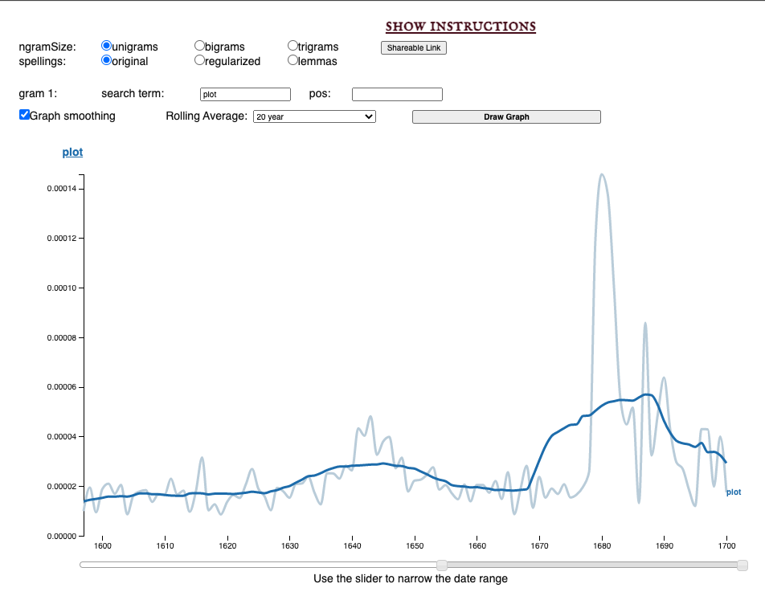

## Lexical analysis - Tools

- Voyant - (voyant-tools.org)
- Ant Conc (https://www.laurenceanthony.net/software/antconc/)
- CQP Web (https://cqpweb.lancs.ac.uk/)
- Programming language libaries such as R’s tidytext, Python’s NLTK

## Sentiment Analysis

- Sentiment analysis looks for ‘sentiment’: trying to categorise a piece of text as either ‘positive’ or ‘negative’, often by comparing against a vocabulary of words which have been manually categorised by volunteers.
- Can be difficult to use, particularly for historical texts
- Doesn’t take account of the context of a word, or its change in use over time

## Sentiment Analysis - Tools

- Python: NLTK?
- R: tidytext

## Topic modelling

- Topic modelling is the name for the technique of sorting documents into ‘topics’
- Essentially, an algorithm analyses an entire corpus and pulls out ‘topics’: collections of words which appear together. A second step analyses each individual document in the corpus and ranks it according to how much of each topic occurs in it.
- Topic modelling is ‘unsupervised’, which means the algorithm works without any previous input or training.

## Topic modelling

- For example https://dsl.richmond.edu/dispatch/topics which divided a corpus of newspapers into 40 topics and looked at how the proportion of each changed over time.

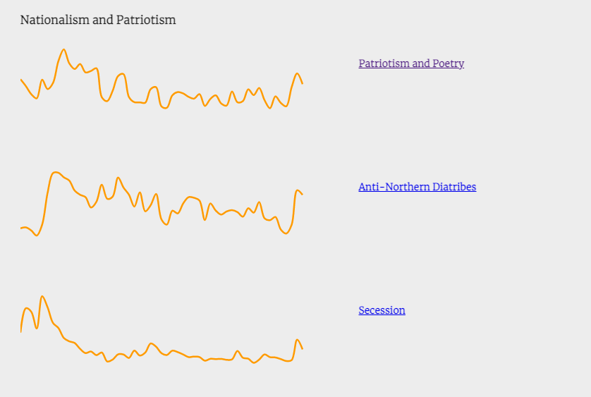

## Topic Modelling - Tools

- MALLETT
- Zotero Paper Machines
- Programming languages

## Natural Language Processing

- Related to some of the above, this is the name for a family of techniques concerned with having computers understand, or parse, human text or speech.
- Google Assistant and Siri, for example, use NLP techniques to understand commands - parsing the meaning of particular words in context. Language tranlations work in a similar way - it’s not enough to translate each word separately but the meaning needs to be extracted.
- Much of the state of the art work here uses machine learning and neural networks to parse text - training a neural network with a large volume of text to detect something of interest (place names, for example).

## Natural Language Processing - Examples

- Named Entity Recognition: extracting structured information (people, places, dates) from unstructured text.

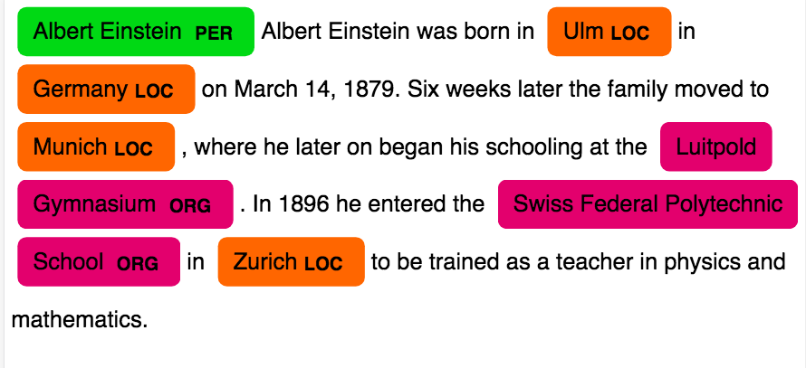

## Natural Language Processing - Examples

- On the *Networking Archives* project we have used NER to extract place names from the seventeenth century Calendars of State Papers, and mapped the changing geography of news reports

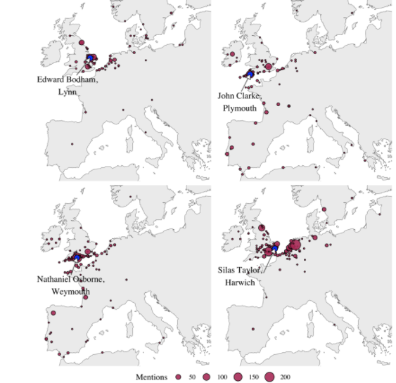

## Natural Language Processing - Tools and Resources

- Voyant Tools
- Stanford NLP
- NLTK
- SpaCy
- Tensorflow and Pytorch/Keras

## Network Analysis

- Network analysis is a way of mathematically modelling the relationship between things. It is formed from two basic parts: a set of things, or entities, in network analysis-speak known as *nodes*, and the links between them, known as edges.
- By mathematically modelling the resulting ‘graph’, we can learn more about the flow of information in a particular system

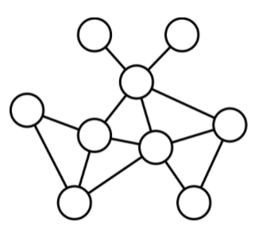

## Network Analysis

- For example, Ruth and Sebastian Ahnert used a measurement called *betweenness centrality* to find what they called ‘sustainers’: individuals in a network of underground Protestant dissenters who didn’t have the most connections, but who served as bridges in a community. In a follow-up project they used clustering to uncover overlooked spies, by comparing their network profile to known spies.
- Other projects have used network analysis to understand and uncover the role of women in intellectual networks in the 17th century

## Network Analysis - how does it work?

- Networks are a way of abstracting phenomena or systems of knowledge into an abstract framework. At its most basic a network is made up of entities, which are described as nodes (or sometimes vertices), and the connections between them, which are known as edges (or sometimes arcs).
- This is often visualised as a network diagram, with nodes represented by circles and the edges as lines between them.
- The resulting digital object is known as a graph, and it can be mathematically analysed and understood
- Many applications of network analysis involve getting a series of metrics, or measurements, about each node which tells us something about its position in the system.

## Network Analysis - degree

- The most basic of these is *degree*: simply a count of the incoming and outgoing connections of a node.

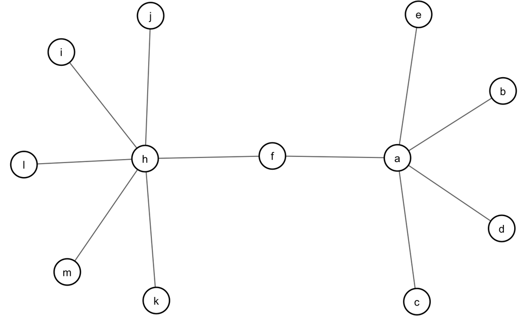

## Network Analysis - betweenness centrality

- For each pair of nodes, there is a ‘shortest path’ through the network. This is the route from one to the other with the least amount of ‘hops’.
- Betweenness centrality is measured by counting up the number of times each node is used in one of these shortest paths. Those with high scores generally ‘bridge’ different parts of the network together.

## Network analysis - different types

- unimodal, bimodal etc
- different types of data that can be used in a network: correspondence, text, different types of relations between things

## Network Analysis - some cool projects

- Tudor Networks of Power

## Network Analysis - Useful tools

- Palladio
- Gephi
- John Ladd’s network tool
- Python, NetworkX
- R, tidygraph, ggraph, igraph

## Mapping - ‘Spatial Humanities’

- A wide range of applications:
  - Applying geospatial analysis to history, literature etc.
  - Analysing the changes in infrastructure by looking at roads on maps
- Also looking at word vectors - Anouk Lang’s work

## Spatial Humanities Projects

- Cameron Blevins,‘Mining and Mapping the Production of Space’
- Looked for changes in place mentions in 19th century American newspapers (https://web.stanford.edu/group/spatialhistory/cgi-bin/site/pub.php?id=93)

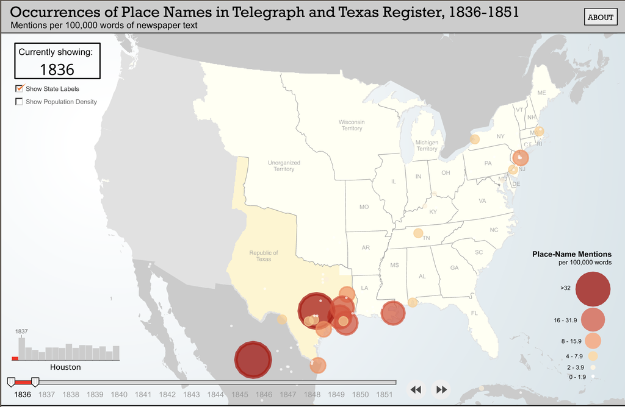

- Rachel’s itinerary project - CESTA

## Spatial Humanities Projects

- Viabundus

## Projects - Geography of the Post

[figure not shown]

## Different types of spatial data

- Most common are points, lines, polygons and rasters

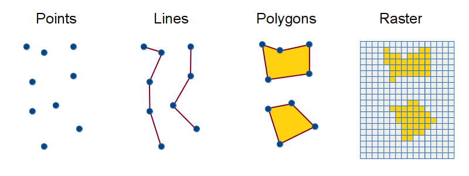

## Tools:

- Palladio
- GIS software like QGIS
- Again, R (sf) and Python!

## Mapping - data needed

- First you need to gather coordinates (for point data). Each location needs a latitude and longitude to be mapped
- This can be added manually or with a geocoding service or with something like Geonames.
- You can then add additional data to the points - sizing by a numerical value or colouring by category, for example

## Diving deeper into DH

- Data vs Capta
- Bias issues.
- What data are we using? Who created it?
- What parts of the world are represented?
- Using tools made for other purposes (catching spies etc)
- What is DH not good at? Quote data feminism and algorithms of oppression?

## Where to publish

- Range of journals. Is it better to publish in DH or general?
- Difference between the publishing model for science and humanities, where does DH sit?

## Where to get funding?

- Small projects
- Labs like KDL and DHI Sheffield